# QMM1002 Case Study 2

Himanshu Bairagi

A00263144

Due: April 21, 2023 at 11:59PM

## **Introduction**

Time management is one of the most critical aspects of a student’s life. Efficiently managing classes, studies, and physical and mental health is significant for all-rounded success. This case study aims to understand essential aspects of everyday life and the differences among the students from the three analytics programs at Cambrian College: BAPG, CAGC, and HAGC. After this study, we should be able to provide answers to three key questions. Are there differences in the average study times for students in the different analytics streams? Is the distribution of days studied more than 3.13 hours (the average daily study time for students at McGill) the same for students in the different analytics streams? How does my study time change over time?

The data points for this study are a combination of quantitative and categorical characteristics. Semester (F22, W23) and Program (BAPG, CAGC, HAGC) are the categorical factors. The quantitative factor is the time spent studying (time in hours). Only the data from September 12, 2022, to April 5, 2023, is used in this study. The dataset’s level of granularity is day level.

Date, Study Hours, Semester, and Program are the variables I’ve chosen. I chose these variables because I wanted to understand if there is a change in my study hours across the fall and winter semesters and to analyze the differences in the study patterns of students from BAPG, HAGC, and CAGC programs.

| Variable | Type |
| --- | --- |
| Date | Identifier |
| Study Hours | Quantitative |
| Semester (F22, W23) | Categorical |
| Program (BAPG, CAGC, HAGC) | Categorical |

**Summary Statistics - Study Hours**

| Data Set | Mean | Standard Deviation |
| --- | --- | --- |
| Personal | 4.1693989 | 1.8571937 |
| Personal (Fall Semester) | 4.46875 | 1.9944825 |
| Personal (Winter Semester) | 3.8390805 | 1.6415645 |
| All Students | 3.5666611 | 2.3061209 |
| BAPG | 3.3382567 | 2.2996478 |
| CAGC | 4.079602 | 2.545816 |
| HAGC | 3.8118149 | 2.1271117 |

## **Data Analysis**

### Part 1: ANOVA

**Objective:** Determine if the mean number of hours studied by students from the three programs: BAPG, CAGC, and HAGC are same or diferent.

**Hypothesis:**

$H_0: \mu_B = \mu_C = \mu_H$

$H_A:$ At least one mean is different

```r
# ANOVA summary
summary(anova_combined_50)
```

```
##              Df Sum Sq Mean Sq F value  Pr(>F)
## Program       2   57.7  28.852   5.448 0.00522 **
## Residuals   147  778.5   5.296
## ---
## Signif. codes:  0 '***' 0.001 '**' 0.01 '*' 0.05 '.' 0.1 ' ' 1
```

```r
# Calculate the critical F-value
qf(0.05, df1 = 2, df2 = 147, lower.tail=FALSE)
```

```
## [1] 3.057621
```

Since,

- F-value = 5.448 > 3.057621 = critical f-value
- p-value = 0.00522 < 0.05 = alpha

**Decision:** Reject the null hypothesis.

**Inference:** There is evidence that the mean number of hours studied in the three programs are different.

**Check Conditions for ANOVA:**

- Independence Assumption: The experiment uses randomized data from the three programs. Study hours of students of one program does not affect the study hours of students of other programs.
- Similar Variance Assumption: There are some differences specifically between BAPG and HAGC, but overall the variances are quite similar.

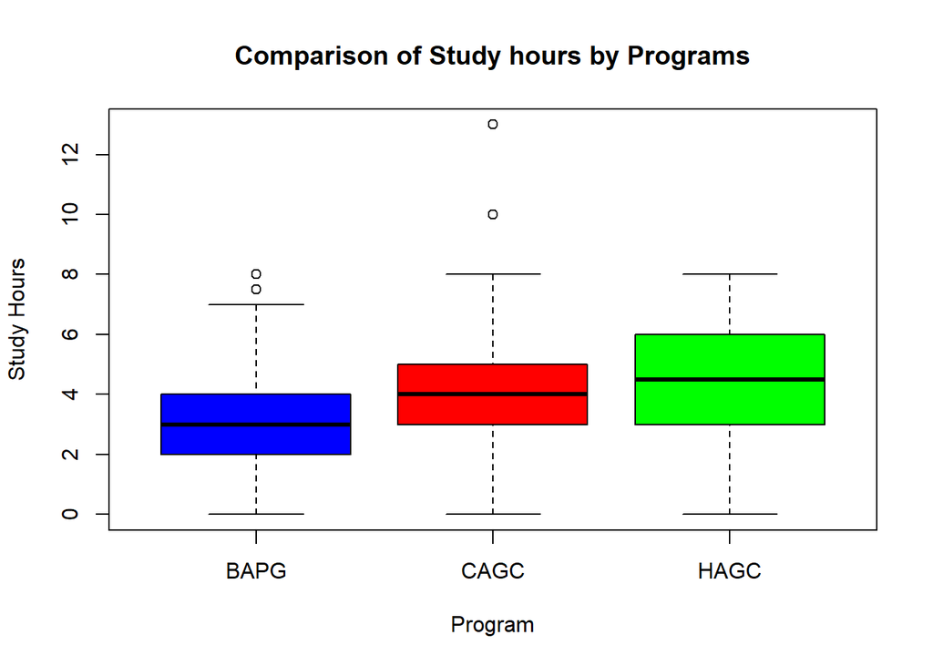

```r
# boxplot for comparison
boxplot(Study~Program, data=combined_50,
        main="Comparison of Study hours by Programs",
        ylab="Study Hours", xlab="Program", col=c("blue","red","green"))
```

- Normal Population Assumption: The distribution of residuals is nearly normal.

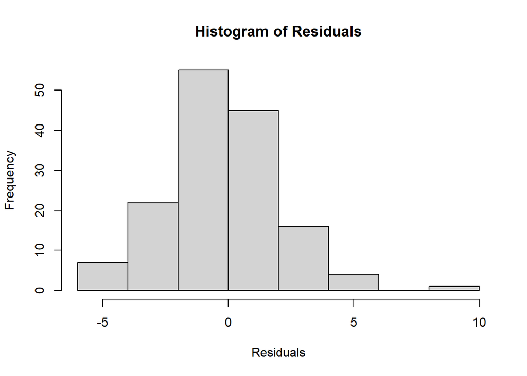

```r
# Histogram of residuals plot
hist(anova_combined_50$residuals,
     main="Histogram of Residuals",
     xlab="Residuals")
```

**Tukey’s HSD:**

```r
# Tukey's HSD
TukeyHSD(anova_combined_50, conf.level=0.95)
```

```
##   Tukey multiple comparisons of means
##     95% family-wise confidence level
##
## Fit: aov(formula = Study ~ Program, data = combined_50)
##
## $Program
##            diff       lwr      upr     p adj
## CAGC-BAPG  1.34  0.250259 2.429741 0.0115214
## HAGC-BAPG  1.29  0.200259 2.379741 0.0157713
## HAGC-CAGC -0.05 -1.139741 1.039741 0.9935150
```

Since,

- p-value (CAGC-BAPG) = 0.0115214 < 0.05 = alpha -> CAGC & BAPG are different.
- p-value (HAGC-BAPG) = 0.0157713 < 0.05 = alpha -> HAGC & BAPG are different.

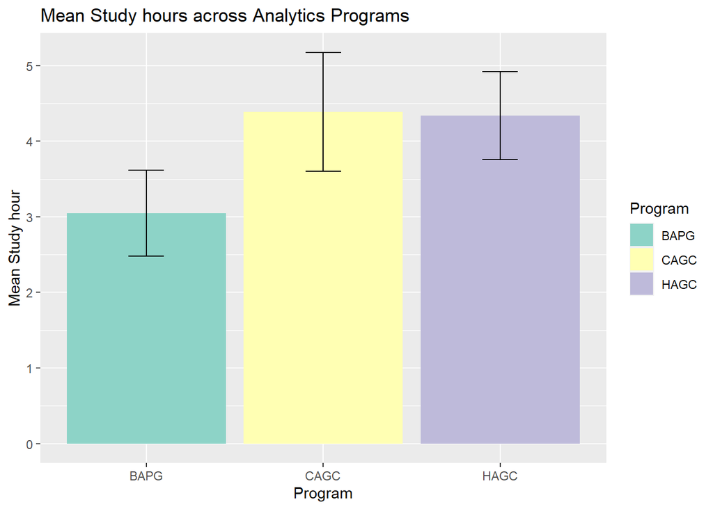

```r
# create plot
ggplot(combined_50, aes(Program, Study, fill=Program))+
  stat_summary(fun=mean, geom="bar")+
  stat_summary(fun.data=mean_cl_normal, geom="errorbar", width=0.2)+    labs(x="Program", y="Mean Study hour", title="Mean Study hours across Analytics Programs")+     scale_fill_brewer(palette="Set3")
```

**Inference:** Students in CAGC and HAGC programs spend significantly higher hours studying than students in BAPG program.

### Part 2: Chi-Square Tests

**Objective:** Determine if there is evidence that the distribution of days with average study hours above 3.13 hours and average study hours below 3.13 hours is the same across programs.

**Hypothesis:**

$H_0:$ Study hours and type of program are independent

$H_A:$ Study hours and type of program are not independent

**Chi-square statistics:**  
X-squared = 12.972  
p-value = 0.001525  
X^2* (critical value) = 5.991465  
alpha = 0.05

**Residuals:**

| Study Hours | BAPG | CAGC | HAGC |
| --- | --- | --- | --- |
| Above | -1.8569534 | 0.5570860 | 1.2998674 |
| Below | 2.1821789 | -0.6546537 | -1.5275252 |

Since,

- x-squared = 12.972 > 5.991465 = X^2* or critical value
- p-value = 0.001525 < 0.05 = alpha)

**Decision:** Reject the null hypothesis.

**Inference:** There is a difference in the above and below study hours across different program types.

**Check conditions for chi-square test of independence**

- Counted Data Condition: Categories “Above” and “Below” are counted.
- Independence Condition: Counts are independent since the data is randomly selected.
- Randomization Condition: Samples randomly selected from the combined data for BAPG, HAGC, CAGC.
- Sample Size Condition: 150 random samples > 5.

[figure not shown]

```r
# transpose observed data
observed_hours_trans <- t(observed_hours)

# association plot
assocplot(observed_hours_trans, xlab="Average Study Hours", ylab="Program", main="Association Plot for Beverages")
```

**Inference:** Students in BAPG have more less above average (> 3.13 hours), and high below average days. This supports the conclusion that above and below study hours for BAPG students is different than HAGC and CAGC students.

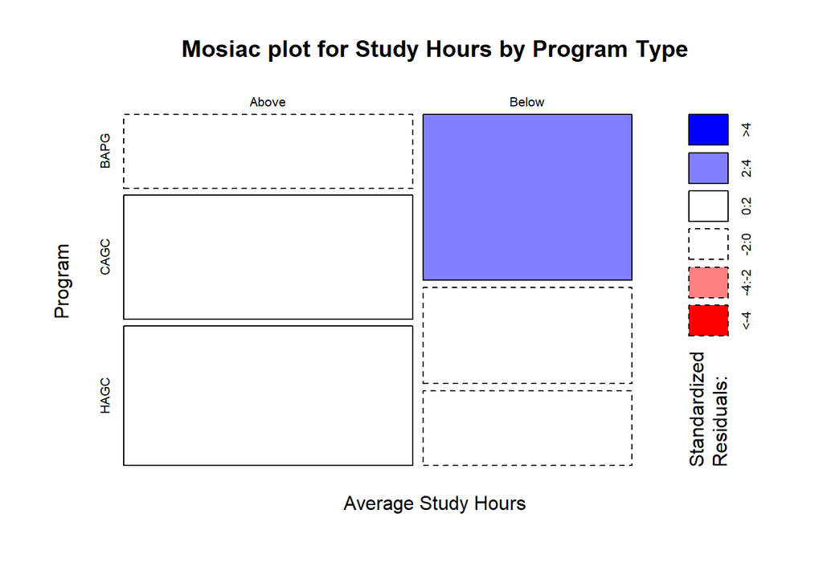

```r
# mosaic plot
mosaicplot(observed_hours, xlab="Average Study Hours", ylab="Program",shade = TRUE, main = "Mosiac plot for Study Hours by Program Type")
```

**Inference:** The heights of the standardized residuals of above and below average study hours of BAPG students are roughly the double than CAGC and HAGC. However, the standardized residual is under the threshold of 3. It can be concluded that BAPG’s below average study hours are the most unusual and not the same amount that was expected. The other bar heights do not look significant different (the residuals are not unusual)

### Part 3: Time Series Analysis

**Objective**: Time series analysis of study hours to predict expected study hours for the upcoming two weeks.

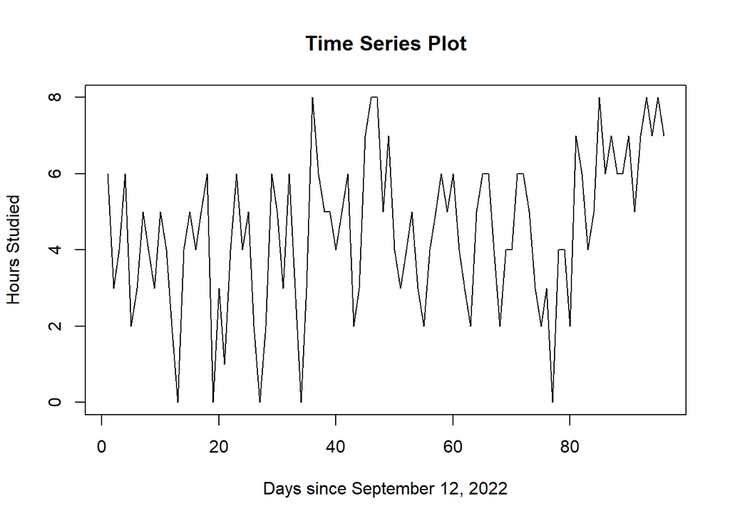

```r
# plot study hours
plot.ts(ts_personal_study_hours, xlab="Days since September 12, 2022", ylab="Hours Studied", main="Time Series Plot")
```

```r
# decompose the time series
# plot(decompose(ts_personal_study_hours))

# The time series object could not be decomposed as the longest stretch of contiguous data does not span across two periods.
```

**Error metrics**

| Model | ME | RMSE | MAE | MASE |
| --- | --- | --- | --- | --- |
| SES | 0.04530762 | 1.92417 | 1.570811 | 0.8726729 |
| HES | 0.3069638 | 2.318396 | 1.885384 | 1.047436 |

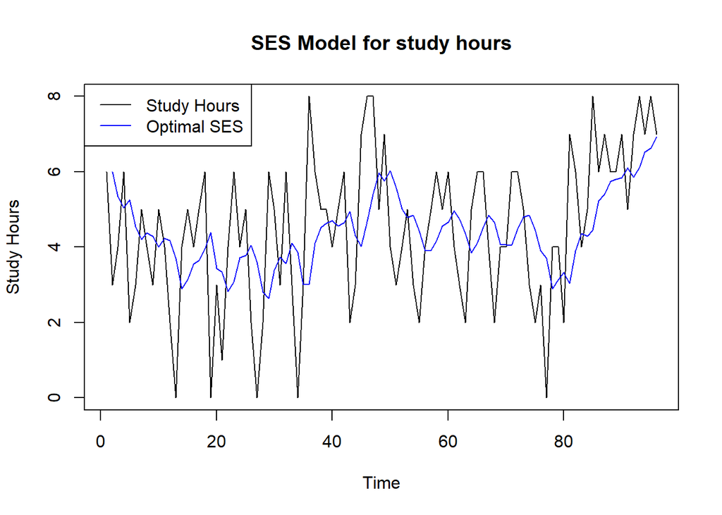

```r
# plot
plot.ts(cbind(ts_personal_study_hours, ses_personal_study_hours$fitted[,1]), col=c("black", "blue"), plot.type="single",
        ylab="Study Hours", main="SES Model for study hours")
legend("topleft", legend=c("Study Hours", "Optimal SES"),
       col=c("black", "blue"), lty=1)
```

**Weighting Parameters**  
alpha = 0.2195282

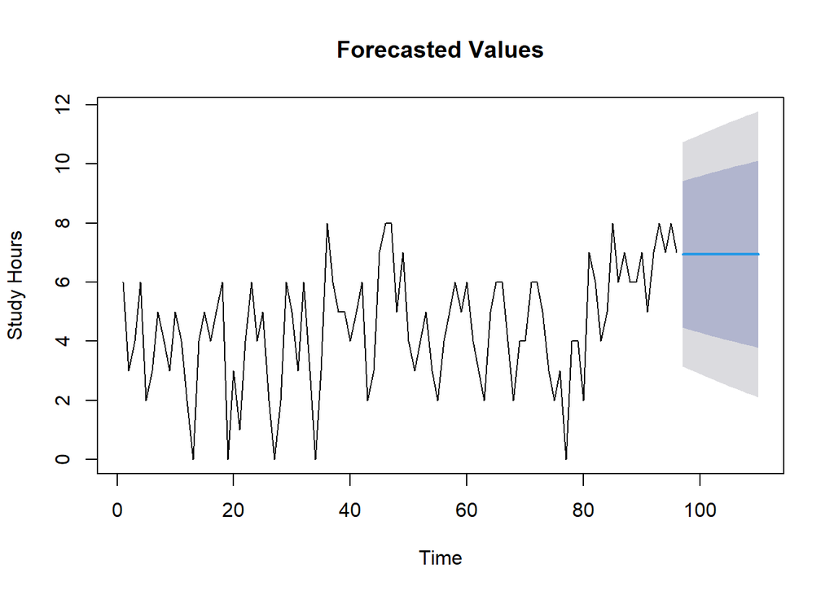

```r
# plot forecast
plot(forecast_personal_study_hours, xlab="Time", ylab="Study Hours", main="Forecasted Values")
```

## **Conclusion**

Analysis Summary:

**Questions**